# Tamanho ou Magnitude do Efeito

## 🧠 Tamanho ou Magnitude do Efeito

## 🔢 O que significa?

A interpretação do tamanho do efeito diz respeito ao "impacto prático" ou à "relevância real" da diferença ou associação encontrada.

- Enquanto o valor-p responde: “Existe algum efeito?”
- O tamanho do efeito responde: “Quão grande é esse efeito? Ele é relevante na prática?”

## 📱 Tipo de Magnitude

O tipo de tamanho de efeito depende diretamente do tipo de teste estatístico que você está realizando. Cada teste tem uma medida de efeito apropriada, que expressa o grau da diferença, associação ou explicação observada. Aqui vai uma tabela-resumo com os principais exemplos:

| Tipo de Teste | Medida de Tamanho de Efeito | Símbolo | Interpretação comum (pequeno / médio / grande) |
| --- | --- | --- | --- |
| Comparação de duas médias (teste t) | Cohen's d | *d* | 0.2 / 0.5 / 0.8 |
| ANOVA (3 ou mais grupos) | Eta quadrado parcial ou f | *η²* / *f* | 0.01 / 0.06 / 0.14 (*η²*) ou 0.1 / 0.25 / 0.4 (*f*) |
| Regressão Linear | Cohen's f² | *f²* | 0.02 / 0.15 / 0.35 |
| Correlação de Pearson | r de Pearson | *r* | 0.1 / 0.3 / 0.5 |
| Qui-quadrado (proporções) | w de Cohen (ou Phi) | *w* | 0.1 / 0.3 / 0.5 |
| Regressão logística | Odds Ratio ou R² de Nagelkerke | OR / *R²* | OR: referência clínica, *R²* ~ semelhante ao *f²* |
| Análise de sobrevivência (ex: Log-rank) | Hazard Ratio | HR | Sem cut-offs fixos: depende da área clínica |

## 😎 Exemplos

#### 🧪 Cohen’s d (Comparação de Médias)

Cohen’s d é uma medida de tamanho do efeito padronizado usada para expressar a diferença entre duas médias em termos de desvios padrão.

**Fórmula**

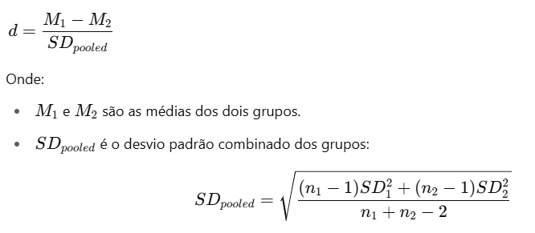

| d | Interpretação típica | Exemplo clínico |
| --- | --- | --- |
| 0.2 | Pequeno | Diferença de 2 mg/dL em colesterol |
| 0.5 | Médio | Diferença de 10 mmHg na pressão |
| 0.8 | Grande | Diferença de 30 pontos na glicemia |

OBS: Mesmo uma diferença pequena (como 0.2) pode ser relevante em contextos populacionais ou quando o desfecho for muito importante (ex: mortalidade).

#### 🔗 r de Pearson (Correlação)

É uma medida da força e direção da associação linear entre duas variáveis quantitativas.

**Fórmula:**

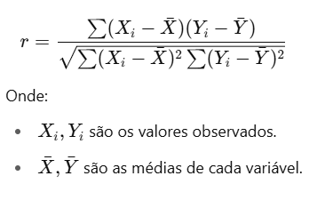

| r | Interpretação típica | Exemplo em saúde |
| --- | --- | --- |
| 0.1 | Fraca | Idade e consumo de frutas |
| 0.3 | Moderada | IMC e risco de hipertensão |
| 0.5+ | Forte | Tabagismo e risco de câncer pulmonar |

OBS: Mesmo uma correlação de 0.3 pode ser muito relevante se envolver uma relação com desfecho importante, como mortalidade ou doenças graves.

## 🤔 Cenários para Interpretação

###### **“Significância sem importância”**

Valor-p significativo, mas efeito irrelevante: Em amostras muito grandes, até diferenças mínimas e irrelevantes na prática clínica podem gerar um valor-p muito pequeno, indicando “significância estatística”.

Exemplo:

- Redução de 1 mmHg na pressão arterial.
- População: 5.000 pacientes
- Comparação: Novo medicamento vs. padrão
- Resultado: Diferença média: -1 mmHg. Desvio padrão: 12 mmHg. Cohen’s d ≈ 0.08 (efeito desprezível). p < 0.001

❌ Interpretação equivocada: “O medicamento funciona!”

✅ Interpretação correta: A diferença é estatisticamente significativa, mas clinicamente irrelevante — ninguém muda a conduta por 1 mmHg.

###### **“Importância sem significância”**

Efeito grande, mas valor-p não significativo: Em amostras pequenas, mesmo efeitos grandes e relevantes podem não atingir o valor-p < 0.05 — por falta de poder estatístico.

Exemplo:

- Redução de 10 mmHg com nova droga
- População: 10 pacientes por grupo
- Resultado: Diferença média: -10 mmHg. Desvio padrão: 12 mmHg. Cohen’s d ≈ 0.83 (grande). p = 0.07

❌ Interpretação equivocada: “O medicamento não funciona.”

✅ Interpretação correta: O efeito é potencialmente relevante, mas não conseguimos provar com segurança devido à amostra pequena. A recomendação seria repetir o estudo com mais pacientes.